# Modelle und Messbarkeit der Resilienz

Cyber Security Management · Termin 2

Prof. Dr. Dirk Loomans

Hochschule Mainz · dirk.loomans@hs-mainz.de

## Agenda

- Rückblick & Lernziele
- Einstieg: Brand im Rechenzentrum
- Warum Resilienz messen?
- Resilienz als Systemfunktion: die Degradationskurve
- Kennzahlen: RTO, RPO, MTTR, MTBF – und Verfügbarkeit
- Modelle aus Frameworks (NIST, ISO, BSI, ENISA)
- Messmethoden, KPIs und Reifegrade
- Fallbeispiele & Übung: Resilienz bewerten
- Kernpunkte & Ausblick

## Rückblick Sitzung 1

- Resilienz = Widerstands-, Erholungs- **und** Lernfähigkeit – nicht Unverwundbarkeit.
- Safety ≠ Security – beides beeinflusst Resilienz.
- Vier Prinzipien: Redundanz, Diversität, Wiederherstellbarkeit, Adaptivität.
- Die Resilienzkurve: Abfall flacher, Erholung schneller, danach besser.
- Kupferberg: **Ein Backup, das nie getestet wurde, ist eine Hoffnung.**

[figure not shown]

## Lernziele

Nach dieser Sitzung können Sie …

- erklären, warum Resilienz **messbar** gemacht werden muss,
- die Kennzahlen **RTO, RPO, MTTR und MTBF** definieren und als Ziel- oder Messwert einordnen,
- Resilienzmodelle in **NIST, ISO/IEC 27031, BSI 200-4 und ENISA** verorten,
- die **Degradations- und Wiederherstellungskurve** eines Systems qualitativ beschreiben,
- erste **Reifegrad- und KPI-basierte Bewertungen** realer IT-Systeme vornehmen.

## Einstieg: Brand im Rechenzentrum

- **10. März 2021, Straßburg:** Das Rechenzentrum SBG2 von OVHcloud brennt vollständig aus, SBG1 wird beschädigt
- Betroffen u. a. data.gouv.fr und die Website des Centre Pompidou
- Manche Kunden hatten ihr Backup im **selben Gebäude** wie die Produktion – beides war weg
- 2023 verurteilt ein französisches Handelsgericht OVHcloud zu Schadensersatz, weil Backups nicht wie vereinbart getrennt lagen

**Frage:** Wie alt dürfen Ihre Daten nach einer Wiederherstellung sein?

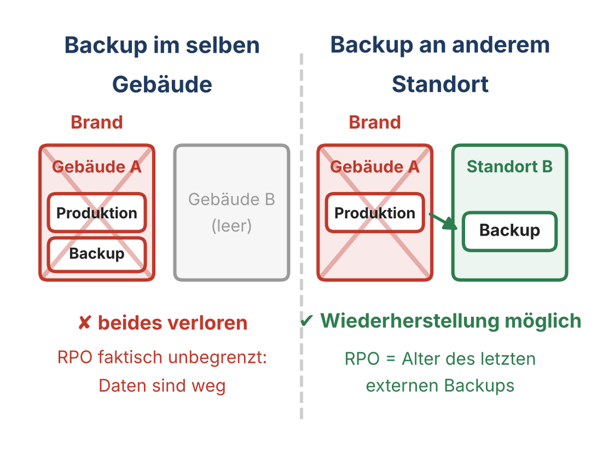

## Warum Resilienz messen?

- **Steuerung:** Management braucht Kennzahlen für Priorisierung und Budget.
- **Vergleichbarkeit** zwischen Systemen und Organisationen.
- **Frühwarnung:** Indikatoren für Krisenfähigkeit.
- **Nachweis:** In regulierten Domänen (KRITIS, Finanzaufsicht) wird quantifizierbare Belastbarkeit erwartet.

Was man nicht misst, kann man nicht verbessern – und nicht nachweisen.

[figure not shown]

## Resilienz als Systemfunktion

- Resilienz ist keine statische Eigenschaft, sondern **Verhalten unter Störung**.
- Systemleistung L(t) über die Zeit → „Degradationskurve“
- Zwei Schlüsselgrößen: **Tiefe des Ausfalls (Δ)** und **Wiederherstellungszeit (tR)**
- Ziel: Minimierung von Δ und tR

Resilienz zeigt sich nicht im Normalbetrieb, sondern in der Auslenkung. Die Kurve misst das Ergebnis, nicht den Weg.

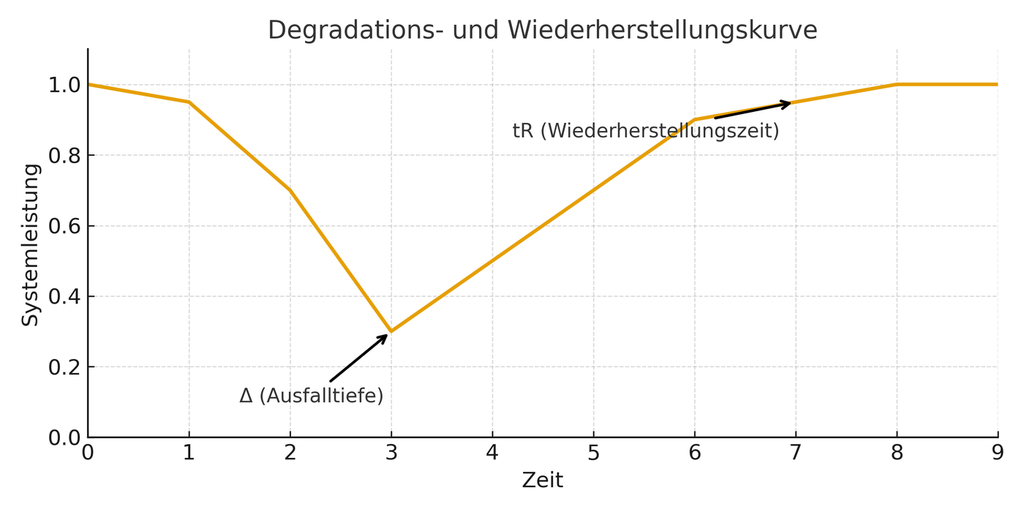

## Grafische Darstellung von RTO und RPO

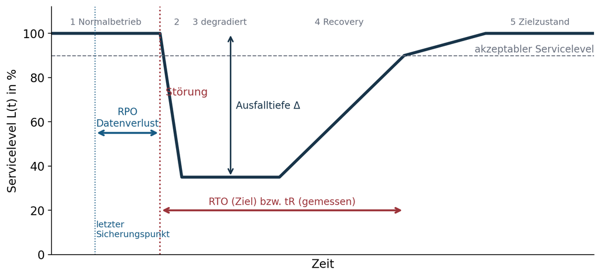

## Resilienzmetriken in der IT

RTO und RPO sind Planungsziele, MTTR und MTBF beobachtete Messwerte.

| Kennzahl | Bedeutung | Beispiel |
| --- | --- | --- |
| RTO | Recovery Time Objective – max. zulässige Wiederherstellungszeit | 2 h für Mailserver |
| RPO | Recovery Point Objective – max. Datenverlust zeitlich | 15 min |
| MTTR | Mean Time to Repair – durchschnittliche Reparaturzeit | 45 min |
| MTBF | Mean Time Between Failures – mittlere Zeit zwischen Fehlern | 30 Tage |

## Ziel vs. Messwert

- **RTO / RPO:** normative bzw. vertragliche Anforderung – „Wie lange dürfen wir offline sein? Wie alt dürfen die Daten sein?“
- **MTTR / MTBF:** beobachtete Realwelt-Performance.
- MTBF misst Zuverlässigkeit, nicht Resilienz – ist aber entscheidend für die Risikoexposition.
- Normen fordern **Angemessenheit**, nicht absolute Minimierung.

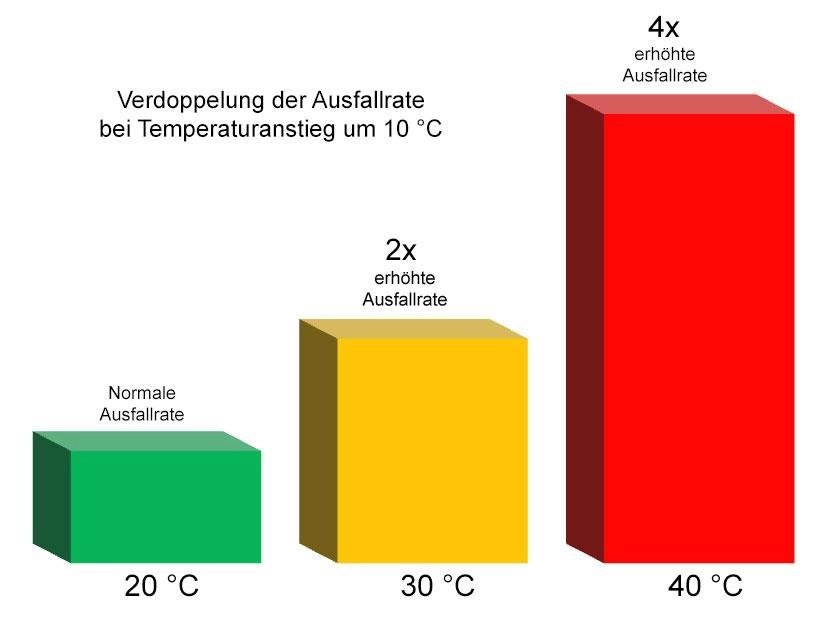

## Verfügbarkeit: MTBF und MTTR zusammen

| Verfügbarkeit | Ausfall pro Jahr |
| --- | --- |
| 99 % | ca. 3,7 Tage |
| 99,9 % | ca. 8,8 Stunden |
| 99,99 % | ca. 53 Minuten |
| 99,999 % | ca. 5 Minuten |

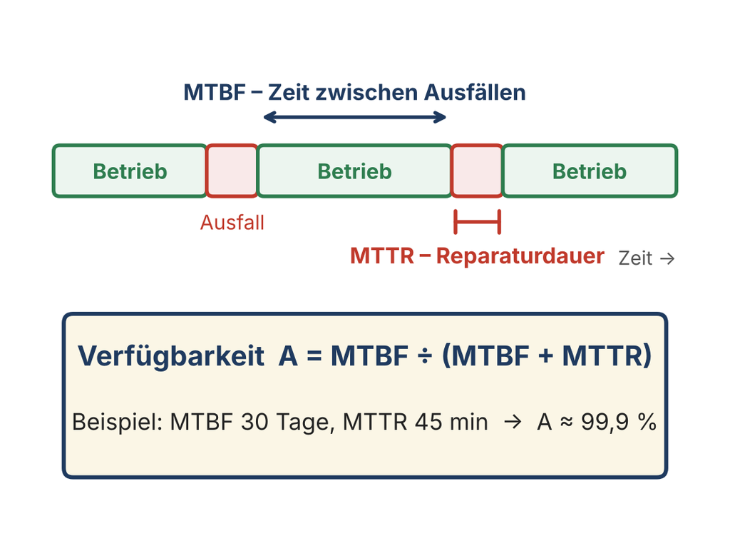

## Ein RPO, das niemand prüfte: GitLab 2017

- Am 31. Januar 2017 löscht ein Administrator versehentlich rund 300 GB auf der **Produktionsdatenbank** statt auf dem Replikat
- Vier Sicherungswege – drei versagen unbemerkt
- Rettung durch einen **zufälligen** Snapshot, 6 Stunden alt
- Ergebnis: ca. 6 h Datenverlust, ca. 18 h Ausfall von GitLab.com
- Ursache laut Postmortem: Niemand war für die Backups verantwortlich, niemand testete sie

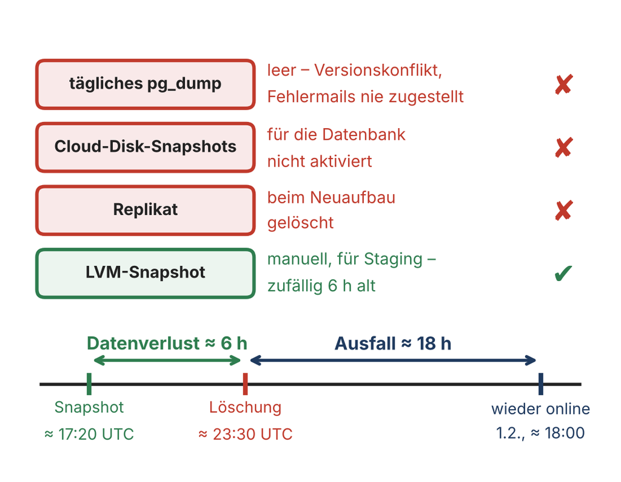

## Modelle aus Frameworks

Frameworks liefern den Ordnungsrahmen, in dem Metriken geplant und bewertet werden.

| Framework | Fokus | Kernelemente |
| --- | --- | --- |
| NIST SP 800-160 Vol. 2 | Cyber Resilience Engineering | Rev. 1: Anticipate, Withstand, Recover, Adapt |
| ISO/IEC 27031 | IKT-Bereitschaft für BC | Vorbereitung, Tests, Wiederherstellung |
| BSI-Standard 200-4 | Business Continuity Management | Stufenmodell, Szenarien, Notfallübungen |
| ENISA | Sektorale Resilienz (KRITIS) | Bedrohungsmodelle, Abhängigkeiten |

## Messgrößen und Frameworks

**Messgrößen erzeugen Evidenz – Frameworks verankern sie strukturell.**

- NIST: Resilienz von Anfang an in Engineering und Architektur
- ISO/IEC 27031: Nachweis- und Testbarkeit statt Dokumentation
- BSI 200-4: bewertet **Organisationen**, nicht nur Systeme
- ENISA: Resilienz über Einzelsysteme hinaus – Lieferketten, KRITIS-Sektoren

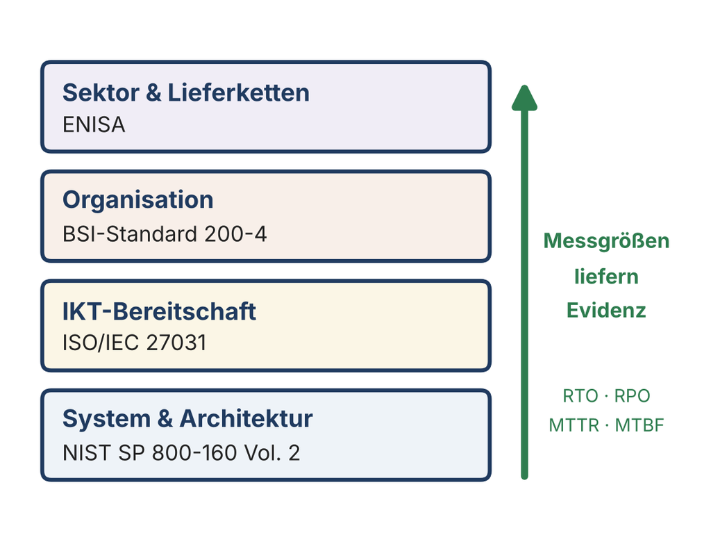

## Messmethoden & KPIs

- **Technisch:** Monitoring, MTTR, Backup- und Restore-Tests
- **Organisatorisch:** BCM-KPIs, Audit-Indikatoren
- **Subjektiv:** Selbstbewertungen, Reifegradanalysen

Je weiter rechts, desto leichter zu erheben – und desto anfälliger für Schönfärberei.

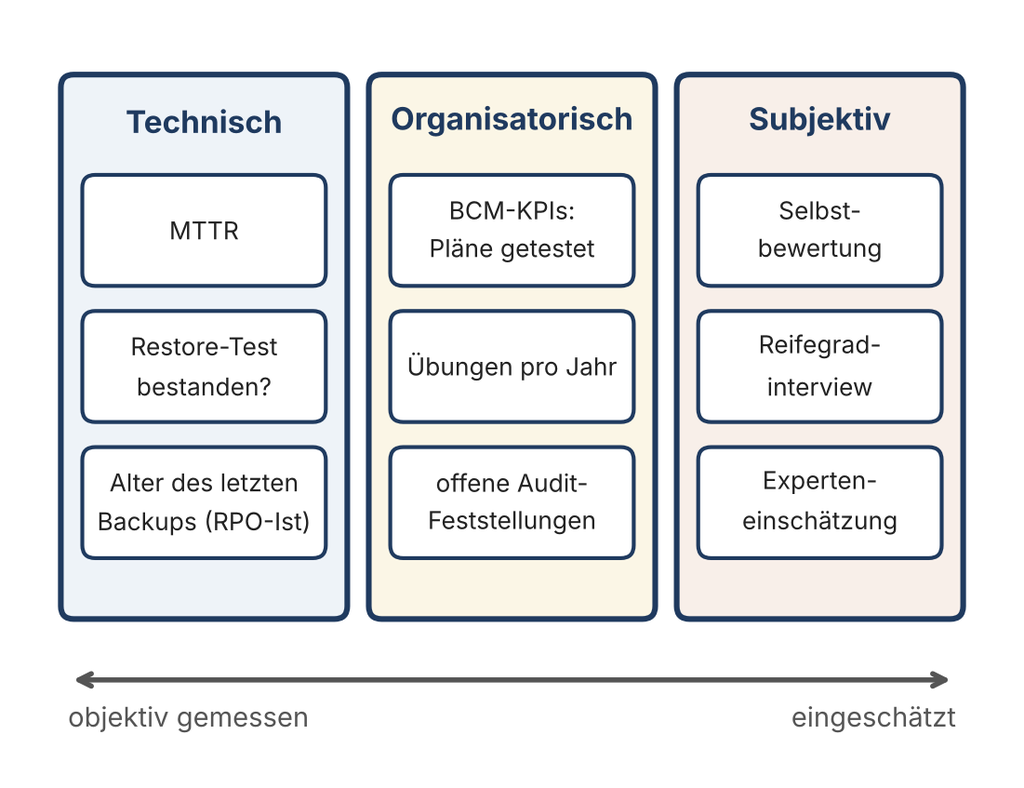

## Resilienzreife (Maturity)

Typischer Entwicklungspfad in fünf Stufen:

1. **Ad hoc** – reaktive Einzelaktionen
2. **Definiert** – Prozesse existieren, wirken noch nicht zuverlässig
3. **Etabliert** – Rollen, Tests, Nachweise, KPIs verankert
4. **Gesteuert** – Messgrößen werden genutzt, Lessons Learned
5. **Optimiert** – kontinuierliche Verbesserung, Resilience by Design

Reifegrad = Fähigkeit *vor* dem Ereignis, nicht Performance danach.

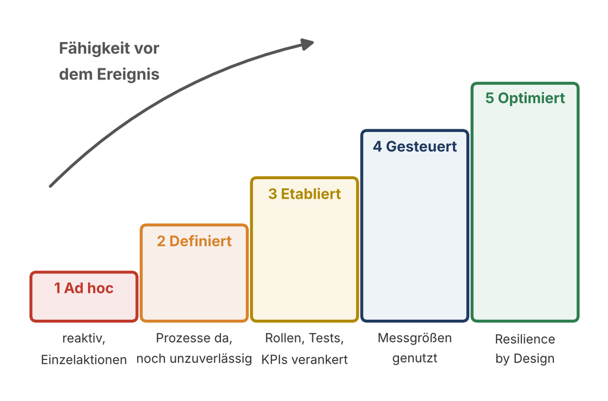

## Reifegrad und Metrik

- RTO-Ziel existiert, Recovery-Test nie durchgeführt → geringer Reifegrad trotz Kennzahl.
- MTTR sinkt über die Zeit → Hinweis auf lernende Organisation.
- RPO definiert und Backups getestet → Evidenz statt Policy.

**Hoher Reifegrad ohne gemessene Recovery ist Papiersicherheit; gemessene MTTR ohne organisatorischen Rahmen ist Zufallssicherheit.**

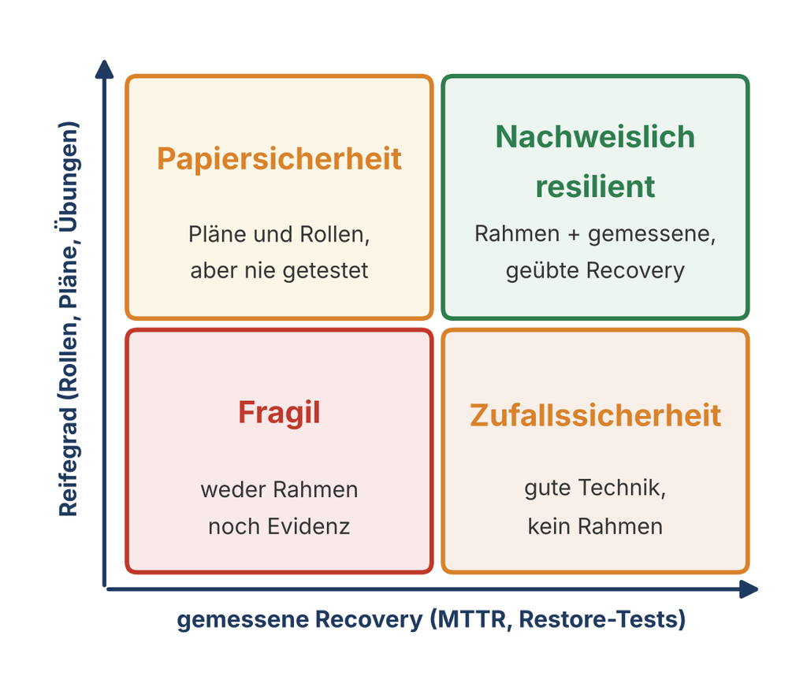

## Fallbeispiel Cloud-Ausfall: AWS 2021

- **7. Dezember 2021, Region us-east-1:** Eine automatisierte Skalierung überlastet das interne AWS-Netz
- Netz rund 7 h gestört, einzelne Dienste bis zu 11 h
- Laufende Instanzen arbeiten weiter – **neue** starten nicht; auch Monitoring und Statusseite sind beeinträchtigt
- Single-Region-Kunden offline, Multi-Region-Kunden schwenken um

**Architektur, nicht Plattform, entscheidet über Resilienz.**

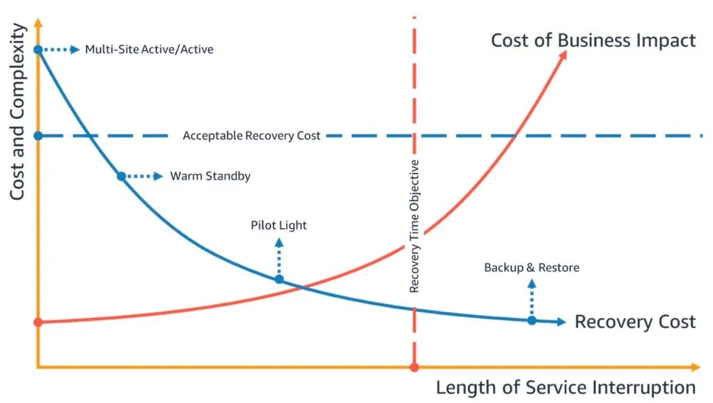

## Gleiche Störung, andere Kurve

- **Ransomware in einer Kommunalverwaltung:** Totalausfall, mehrtägiger Notbetrieb, Restore nur aus Offline-Backups – niedrige Resilienz trotz vorhandener Backups
- **Multi-Region-Failover:** kurzer Einbruch, nach Minuten zurück
- **Cloud-Gaming-DDoS:** langsamer statt ausgefallen (Rate-Limiting, Warteschlangen) – Graceful Degradation statt Hard-Fail

Resilienz bewertet nicht, ob ein Ereignis eintritt, sondern wie ein System danach aussieht.

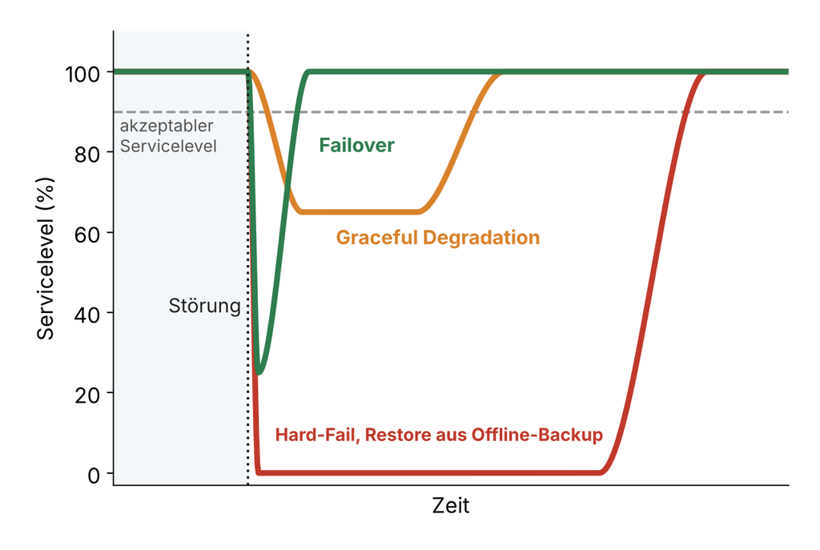

## Übung: Resilienz bewerten

Gruppenarbeit (20–30 Minuten): Wählt ein bekanntes IT-System – Uni-E-Mail, Cloud-Speicher, Banking-App, Cloud-Gaming, Krankenhaus- oder Verwaltungs-IT, Smart Home.

1. **Metriken schätzen:** Welches RTO, welches RPO wäre angemessen? Ist die MTTR aus Statusseiten oder Incidents erkennbar?
2. **Reifegrad einordnen:** ad hoc oder vorbereitet? Hinweise auf Übungen, DR-Tests, Chaos Engineering? Single Points of Failure?
3. **Fazit:** resilient, bedingt resilient oder fragil – und warum?

Ergebnis: 1–2 Folien oder höchstens fünf Stichpunkte je Dimension.

## Bewertungsraster für die Übung

Das Raster hilft, die drei Schritte der Übung strukturiert festzuhalten.

| Dimension | Leitfrage | Ihre Einschätzung |
| --- | --- | --- |
| RTO | Wie lange darf der Dienst ausfallen? |  |
| RPO | Wie viel Datenverlust ist tolerierbar? |  |
| MTTR | Wie schnell kam der Dienst bisher zurück? |  |
| Reifegrad | Stufe 1–5, mit Begründung |  |
| Matrix-Feld | Fragil, Papier-, Zufallssicherheit oder resilient? |  |

## Kernpunkte

- Resilienz zeigt sich **nicht im Normalbetrieb**, sondern im Verlauf von Störung und Wiederherstellung.
- **RTO/RPO sind Zielgrößen, MTTR/MTBF Messgrößen** – beide sind notwendig.
- Frameworks (NIST, ISO, BSI, ENISA) schaffen Verbindlichkeit und Vergleichbarkeit.
- Reifegradmodelle bewerten die **Fähigkeit vor dem Ereignis**.
- Ein Ziel ohne Test ist Papier: Erst der Restore zeigt das echte RPO.

## Ausblick & Hausaufgabe

**Nächste Sitzung:** Resilienz-Architekturen – Redundanz, Diversität, Wiederherstellbarkeit und Adaptivität in hybriden Systemen (On-Prem + Cloud).

**Hausaufgabe:** Recherchieren Sie ein reales IT-Ereignis (z. B. AWS-Ausfall, Ransomware-Vorfall, Rechenzentrumsbrand). Wie schnell wurde der Dienst wiederhergestellt (tR), welche Daten gingen verloren (RPO-Ist)? Zeichnen Sie die Kurve.

Kapitel zum Termin · Skript · Glossar · Quellen